# BrushStrokes QML Type

A brush strokes noise effect. More...

| Import Statement: | `import QtQuick3D.Effects 6.9` |
| --- | --- |
| Status: | Deprecated since 6.5 |

**This type is deprecated since QtQuick3D.Effects 6.5. We strongly advise against using it in new code.**

- [List of all members, including inherited members](https://doc.qt.io/qt-6.9/qml-qtquick3d-effects-brushstrokes-members.html)

## Properties

- **brushAngle** : real
- **brushLength** : real
- **brushSize** : real
- **noiseSample** : TextureInput

## Detailed Description

Use ExtendedSceneEnvironment, MultiEffect, or user-defined effects via the Effect type instead.

**Warning:** All pre-made standalone effects in [QtQuick3D](https://doc.qt.io/qt-6.9/qtquick3d-qmlmodule.html).Effects are considered deprecated starting with Qt 6.5. Applications are advised to use ExtendedSceneEnvironment or MultiEffect instead, when applicable, or alternatively provide their own custom post-processing effect via the Effect type.

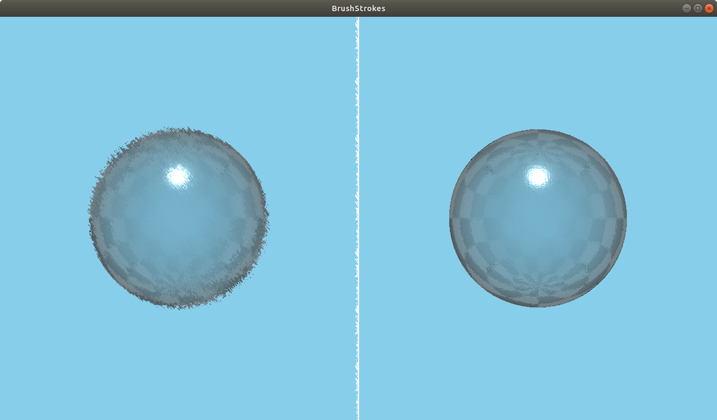

The BrushStrokes effect simulates an artistic painting of the image.

## Property Documentation

### brushAngle : real

The amount to rotate the brush noise texture, in degrees. The default value is `45`.

### brushLength : real

How far to offset the image with the brush. Sensible values are in the range `[0...3]`. The default value is `1`.

### brushSize : real

The scale of the brush. Smaller values yield larger sizes. Sensible values are in the range `[10...200]`. The default value is `100`.

### noiseSample : TextureInput

The brush noise texture map. Default is a Texture with source `"maps/brushnoise.png"`.

© The Qt Company Ltd  
Licensed under the GNU Free Documentation License, Version 1.3.  
https://doc.qt.io/qt-6.9/qml-qtquick3d-effects-brushstrokes.html